# Kucma_Kamil_projekt2

Dane do projektu zostały pobrane ze strony kaggle: https://www.kaggle.com/datasets/vicsuperman/prediction-of-music-genre

Przedstawiają one kilkadziesiąt tysięcy utworów muzycznych opisanych za pomocą kilkunastu bardziej lub mniej mierzalnych zmiennych takich jak popularność, tempo czy akustyczność. Do każdego z nich została przypisana jedna z dziesięciu gatunków muzycznych. Ze względu na duży rozmiar danych, zarówno pod względem liczby danych, liczby zmiennych i liczby grup, ograniczyłem liczbę danych do pięciu tysięcy, liczbę zmiennych do czterech, które mają największe znaczenie w przydziale do danego gatunku, a liczbę gatunków muzycznych do dwóch, znacząco się różniących.

Każdy utwór jest opisany za pomocą zmiennych: acousticness: Miara pewności od 0 do 1 określająca, czy utwór jest akustyczny. 1 oznacza pewność, że utwór jest akustyczny. danceability: Opisuje, w jakim stopniu utwór nadaje się do tańca w oparciu o kombinację elementów muzycznych, takich jak tempo, stabilność rytmu, siła uderzenia i ogólna regularność. Wartość 0 jest najmniej taneczna, a 1 najbardziej taneczna. energy: Energia jest miarą od 0,0 do 1,0 i reprezentuje percepcyjną miarę intensywności i aktywności. Zazwyczaj energiczne utwory wydają się szybkie, głośne i hałaśliwe. instrumentalness - Opisuje stopień w którym muzyka nie zawiera wokalu mówionego. 1 oznacza muzykę bez wokalu, a 0 z ciągłym wokalem. music_genre: Gatunek muzyczny, do którego chcemy przydzielić utwór na podstawie pozostałych zmiennych, 0 oznacza muzykę elektroniczną, a 1, muzykę klasyczną

Dane te chcę wykorzystać do nauki i testowania kilku algorytmów machine learningowych służacych do klasyfikacji obiektów do konkretnych grup, w tym przypadku, do sklasyfikowania utworu o danych parametrach do konkretnego gatunku muzycznego.

Na początek importuje wszystkie używane w projekcie biblioteki.

Następnie wczytuję dane oraz sprawdzam ich podstawowe statystyki. Jednoczenśnie randomizuję kolejność danych, aby uniknąć posortowania danych po zmiennej oznaczającej przydział do kategorii, aby algorytm nie wyuczył się fałszywej tendencji.

```
 acousticness  danceability  energy  instrumentalness  music_genre
     0.000717        0.7060  0.9130           0.00458            0
     0.901000        0.1980  0.0313           0.86600            1
     0.830000        0.0701  0.0436           0.89900            1
     0.990000        0.2970  0.0281           0.87700            1
     0.951000        0.3120  0.0336           0.64200            1
          ...           ...     ...               ...          ...
     0.071900        0.7720  0.8840           0.89200            0
     0.008560        0.8220  0.7150           0.02690            0
     0.014900        0.7370  0.8190           0.43500            0
     0.032700        0.2990  0.7920           0.00000            0
     0.988000        0.2330  0.0217           0.81900            1
       acousticness  danceability       energy  instrumentalness  music_genre
count   5000.000000   5000.000000  5000.000000       5000.000000  5000.000000
mean       0.360456      0.502974     0.561754          0.430076     0.387000
std        0.409410      0.210064     0.329442          0.389892     0.487112
min        0.000001      0.060000     0.000792          0.000000     0.000000
25%        0.007598      0.347000     0.236000          0.004948     0.000000
50%        0.104000      0.528500     0.648000          0.394000     0.000000
75%        0.879000      0.668000     0.860000          0.856000     1.000000
max        0.996000      0.979000     0.999000          0.994000     1.000000
```

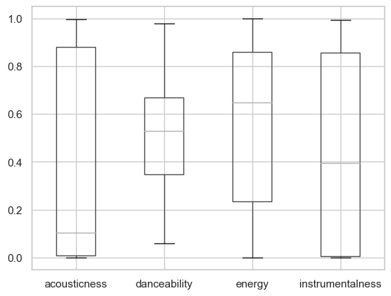

Każda ze zmiennych przyjmuje wartości od 0 do 1, gdzie zmienna wynikowa przyjmuje dokładnie wartość 0 lub 1. Każda ze zmiennych objaśniających przyjmuje wartości z całego lub prawie całego zakresu 0-1, gdzie w przypadku acousticness i intrumentalness dominują mniejsze wartości, a w przypadku danceability i energy wartości te w częściej są większe od 0,5. Pięć tysięcy danych jest wystarczającą liczbą do nauczenia i przetestowania odpowiednich algorytmów.

```
acousticness        0
danceability        0
energy              0
instrumentalness    0
music_genre         0
dtype: int64
           acousticness  danceability     energy  instrumentalness
Wsp.zmien    113.581167     41.764386  58.645194         90.656511
Liczność kategorii muzyka klasyczna:  1935
Liczność kategorii muzyka elektroniczna:  3065
```

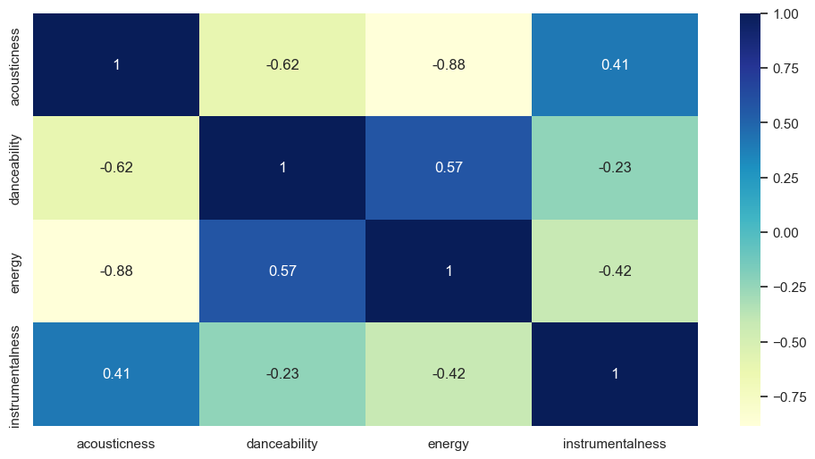

W zestawie danych nie ma żadnych brakujących wartości, zmienne objaśniające nie są ze sobą mocno skolerowane (po za energy - acousticness, ale współczynnik nie przekracza wartości 0,9), a współćzynnik zmienności każdej zmiennej ma dużą wartość. Ze względu na zakres wartości, jakie przyjmują zmienne, nie trzeba się martwić o wartości odstające i standaryzację danych. Obie kategorie, choć nie są równoliczne, to nie są skrajnie różnoliczebne, a charakterystyka danych nie rozróżnia znaczenia w popełnianiu błędu w jedną lub drugą stronę - przypisanie muzyki klasycznej do elektronicznej jest takim samym błędem jak elektronicznej do klasycznej.

```
                                                                        Metoda k najbliższych sąsiadów - KNN
```

Algorytm polega na: porównaniu wartości zmiennych objaśniających dla obserwacji C z wartościami tych zmiennych dla każdej obserwacji w zbiorze uczącym. wyborze k (ustalona z góry liczba) najbliższych do C obserwacji ze zbioru uczącego. uśrednieniu wartości zmiennej objaśnianej dla wybranych obserwacji, w wyniku czego uzyskujemy prognozę.

Na początek z całego zestawu danych wyodrębniam zmienną wynikową, a następnie obie części dzielę na zbiory uczące i testowe w częściach kolejno 4/5 i 1/5

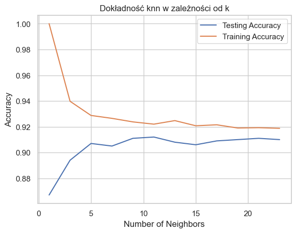

```
{'n_neighbors': 9, 'weights': 'uniform'}
```

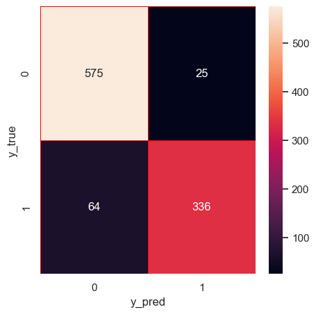

```
Accuracy :  0.911
Sensitivity :  0.9583333333333334
Specificity :  0.84
```

Na początek tworzę wykres dokładności algorytmu na zbiorze uczącym oraz testowym - w jakiej części algorym dobrze przydzielał klasę do posiadanych danych, w zależności od przyjmowanego parametru k - liczby sąsiadów, przyjmowanych w wartościach nieparzystych, aby unikać losowości przydzielania klasy w przypadkach równolicznych, np. dwóch sąsiadów należy do jednej grupy, a dwóch do drugiej, więc przydział następuje losowo. Patrząc oreintacyjnie na pierwszy wykres, który uwzględnia jedynie zmianę liczby sąsiadów, możnaby przyjąć k = 9 za optymalną wartość. Następnie badam wyniki zarówno pod względem liczby sąsiadów jak i sposobu obliczania odległości - k wynosi tyle samo, a wartość uniform oznacza, że odległości od sąsiadów mają taką samą wagę. Otrzymane wartości dokładności, czułości i specyficzności są duże i pozytywnie świadczą o jakości predykcji.

Teraz powtarzam procedurę, tylko dla większej części testowej, a mniejszej uczącej

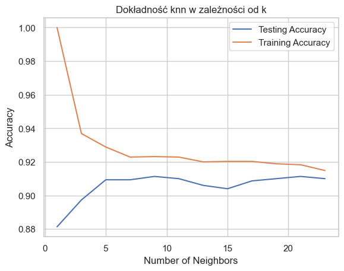

```
{'n_neighbors': 23, 'weights': 'distance'}
```

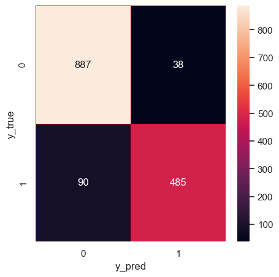

```
Accuracy :  0.9146666666666666
Sensitivity :  0.9589189189189189
Specificity :  0.8434782608695652
```

Otrzymane wyniki są bardzo podobne, a ze względu na większy zakres danych do testowania, można być bardziej pewnym otrzymanych wyników

```
                                                                    Maszyna wektorów nośnych - SVM
```

SVM dedykowane jest głównie do zagadnień klasyfikacji, w których jedną klasę separujemy możliwie dużym marginesem od pozostałych klas. Istotą tej metody jest znalezienie wektorów nośnych, definiujących hiperpowierzchnie optymalnie separujące obiekty w homogeniczne grupy.

W przypadku SVM, główne znaczenie ma wybór rodzaju funkcji jądra. Funkcja jądra to metoda służąca do przyjmowania danych jako danych wejściowych i przekształcania ich w wymaganą formę przetwarzania danych. Funkcją decyzyjną, ze względu na 2 kategorie, jest ovo - one vs one.

```
{'decision_function_shape': 'ovo', 'kernel': 'rbf'}
```

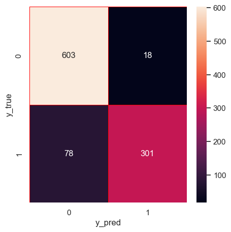

```
Accuracy :  0.904
Sensitivity :  0.9710144927536232
Specificity :  0.7941952506596306
```

Ponownię dziele zbiór na testowy i uczący oraz szukam najlepszych wartości parametrów - rodzaju funkcji jądra z funkcji decyzyjnej. Ze względu na tylko dwie kategorie, jedynym i najlepszym wyborem jest funkcja decyzyjna one vs one, a najlepszą funkcją jądra jest rbf i to dla nich otrzymano powyższe wyniki. Otrzymane wartości dokładności, czułości i specyficzności są duże i pozytywnie świadczą o jakości predykcji.

I ponownie ten sam algorytm, ale dla innych zakresów danych

```
{'decision_function_shape': 'ovo', 'kernel': 'rbf'}
```

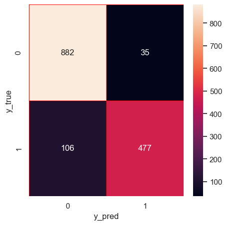

```
Accuracy :  0.906
Sensitivity :  0.9618320610687023
Specificity :  0.8181818181818182
```

```
                                                                                Random forest
```

Algorytm polega na konstruowaniu wielu drzew decyzyjnych w czasie uczenia i generowaniu klasy, która jest dominantą klas (klasyfikacja) lub przewidywaną średnią (regresja) poszczególnych drzew. Pierwszym krokiem jest losowanie ze zwracaniem podzbioru danych (przypadków) z dostępnej próby uczącej. Następnie, powinniśmy stworzyć drzewo dla wylosowanego wcześniej podzbioru. W tym punkcie trzeba sprawdzić, czy dzielony zbiór jest jednorodny oraz czy nie jest zbyt mały, by go podzielić. Należy wylosować pewną liczbę zmiennych objaśniających oraz znaleźć najlepszy podział z wykorzystaniem wylosowanego podzbioru zmiennych. Zbiór ten później dzielimy na dwie części. Jeżeli liczba drzew osiągnie zadane maksimum lub błąd w próbie testowej przestanie maleć, należy zakończyć uczenie. W przeciwnym przypadku, należy wrócić do pierwszego kroku. W ogólności: drzewa "głosują" nad rozwiązaniem, wybór następuje zwykłą większością głosów.

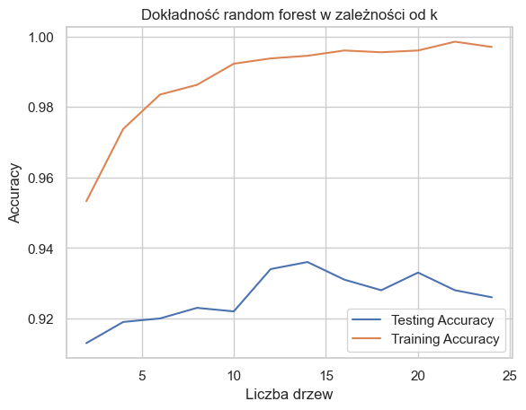

```
{'criterion': 'entropy', 'n_estimators': 14}
```

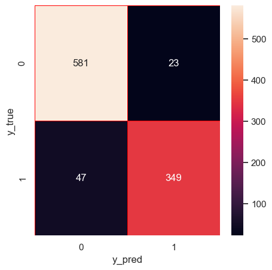

```
Accuracy :  0.93
Sensitivity :  0.9619205298013245
Specificity :  0.8813131313131313
```

Podobnie jak w przypadki knn, na początek sprawdzam wyniki w zależności od przyjmowanej liczby drzew. Patrząc na wykres, można dojść do podobynch wniosków, które zwraca estymacja parametrów, uwzględniająca również wybór odpowiedniej funckji mierzącej jakość podziału drzew - 'entropy'. Otrzymane wartości dokładności, czułości i specyficzności są duże i pozytywnie świadczą o jakości predykcji.

To samo wykonuję dla innego podziału danych

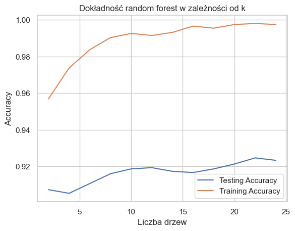

```
{'criterion': 'log_loss', 'n_estimators': 20}
```

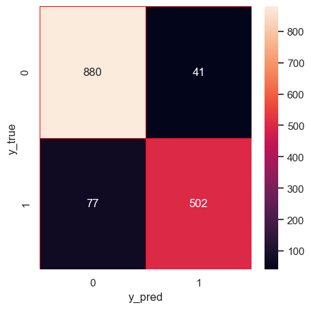

```
Accuracy :  0.9213333333333333
Sensitivity :  0.9554831704668838
Specificity :  0.8670120898100173
```